# Economic and Health Impact of Severe Weather Events in the USA

This study attempts to determine the most impacting weather events in the economy and in the population of the USA.

It addresses the following questions:

1. Across the United States, which types of events are most harmful with respect to population health?
2. Across the United States, which types of events have the greatest economic consequences?

We use [data from the National Weather Services](https://d396qusza40orc.cloudfront.net/repdata%2Fdata%2FStormData.csv.bz2) where information about severe weather events has been recorded from 1950 to 2011.

To measure the impact on population health we adopted the number of casualties recorded on each event as the sum of fatalities and injuries.

To evaluate the impact on the economy, we used the estimated value of damages caused by each weather event recorded on properties and on crops.

## Data Processing

The data for this assignment come in the form of a comma-separated-value file compressed via the bzip2 algorithm to reduce its size, from the following web site:

- Storm Data: *https://d396qusza40orc.cloudfront.net/repdata%2Fdata%2FStormData.csv.bz2*

There is also some documentation of the database available for how some of the variables are constructed/defined:

- National Weather Service Storm Data Documentation: *https://d396qusza40orc.cloudfront.net/repdata%2Fpeer2_doc%2Fpd01016005curr.pdf*
- National Climatic Data Center Storm Events FAQ: *https://d396qusza40orc.cloudfront.net/repdata%2Fpeer2_doc%2FNCDC%20Storm%20Events-FAQ%20Page.pdf*

The events in the database start in the year 1950 and end in November 2011. In the earlier years of the database there are generally fewer events recorded, most likely due to a lack of good records. More recent years should be considered more complete.

### Loading the data

The data for this assignment can be found at the following url as a bzip2 compressed file containing the `repdata-data-StormData.csv` file in csv file format:

- Url: *https://d396qusza40orc.cloudfront.net/repdata%2Fdata%2FStormData.csv.bz2*
- File: *repdata-data-StormData.csv*

The following code will be used to download and read the data into the `StormData` data frame:

```r
temp <- tempfile()
download.file("https://d396qusza40orc.cloudfront.net/repdata%2Fdata%2FStormData.csv.bz2", temp, method="curl")
StormData <- read.csv(bzfile(temp, "repdata-data-StormData.csv"), stringsAsFactors = FALSE)
unlink(temp)
rm(temp)
```

### Analyzing data structure

Let’s analyze the structure of the data loaded:

```r
str(StormData)
```

```
## 'data.frame':    902297 obs. of  37 variables:
##  $ STATE__   : num  1 1 1 1 1 1 1 1 1 1 ...
##  $ BGN_DATE  : chr  "4/18/1950 0:00:00" "4/18/1950 0:00:00" "2/20/1951 0:00:00" "6/8/1951 0:00:00" ...
##  $ BGN_TIME  : chr  "0130" "0145" "1600" "0900" ...
##  $ TIME_ZONE : chr  "CST" "CST" "CST" "CST" ...
##  $ COUNTY    : num  97 3 57 89 43 77 9 123 125 57 ...
##  $ COUNTYNAME: chr  "MOBILE" "BALDWIN" "FAYETTE" "MADISON" ...
##  $ STATE     : chr  "AL" "AL" "AL" "AL" ...
##  $ EVTYPE    : chr  "TORNADO" "TORNADO" "TORNADO" "TORNADO" ...
##  $ BGN_RANGE : num  0 0 0 0 0 0 0 0 0 0 ...
##  $ BGN_AZI   : chr  "" "" "" "" ...
##  $ BGN_LOCATI: chr  "" "" "" "" ...
##  $ END_DATE  : chr  "" "" "" "" ...
##  $ END_TIME  : chr  "" "" "" "" ...
##  $ COUNTY_END: num  0 0 0 0 0 0 0 0 0 0 ...
```

[output cut: 23 more lines]

We notice that there are 902.297 observations with 37 variables.

**Not all variables recorder are of interest to this study!**

We shall use only the following variables that we consider relevant to this study:

- **BGN_DATE** (column 2): Character value with the date in which the event took place in the **MM/DD/YEAR HH:MM:SS** format. We may want to have a look at the evolution of impact in population health and economy with time or at each year.
- **EVTYPE** (column 8): Character value with the type of the event, since we want to explore how each type of event impacts population health and economy. The official table of events is described in item 2.1.1 on page 6 of the [document describing the data](https://d396qusza40orc.cloudfront.net/repdata%2Fpeer2_doc%2Fpd01016005curr.pdf).
- **FATALITIES** and **INJURIES** (columns 23 and 24): Numeric values with the number of fatalities and injuries caused by each event, once we will measure the impact of each type of event in population health by the sum of these two variables.
- **PROPDMG** and **CROPDMG** (columns 25 and 27): Numeric values with an estimate of the value of damages, in properties and in crops, caused by each event, once we will consider measure of the economic impact of each type of event by the sum of these two variables.
- **PROPDMGEXP** and **CROPDMGEXP** (columns 26 and 28): Character values with an alphabetical character suffix to PROPDMG and CROPDMG signifying the magnitude of the number, i.e., 1.55B for $1,550,000,000. Alphabetical characters used to signify magnitude include “K” for thousands, “M” for millions, and “B” for billions.
- **REFNUM** (column 37): Numeric value with an index numner to the specific weather event, just to be able to track back to the event, if necessary.

The remaining variables will not be used in this particular study.

### Subsetting the data

Before we continue digging deeper in the data, we will extract from the data loaded only the rows and columns of interest.

We will create two new data frames:

- **HealthImpact** with data relevant for impact on population health: **BGN_DATE** (column 2), **EVTYPE** (column 8), **FATALITIES** and **INJURIES** (columns 23 and 24)
- **EconomicImpact** with data relevant to economic impact: **BGN_DATE** (column 2), **EVTYPE** (column 8), **PROPDMG** (column 25), **PROPDMGEXP** (columns 26), **CROPDMG** (columns 27), and **CROPDMGEXP** (columns 28)

For that we will use the following code:

```r
HealthImpact<-StormData[StormData$INJURIES > 0 | StormData$FATALITIES > 0, c(2, 8, 23, 24, 37)]

EconomicImpact<-StormData[StormData$PROPDMG > 0 | StormData$CROPDMG > 0, c(2, 8, 25, 26, 27, 28, 37)]

# Remove the big StormData file
rm(StormData)
```

Let’s also adjust some of the columns:

- The character columns for EVTYPE, PROPDMGEXP e CROPDMGEXP to factor variables
- The BGN_DATE to date format

```r
HealthImpact$EVTYPE<-as.factor(HealthImpact$EVTYPE)

EconomicImpact$EVTYPE<-as.factor(EconomicImpact$EVTYPE)

EconomicImpact$PROPDMGEXP<-as.factor(EconomicImpact$PROPDMGEXP)

EconomicImpact$CROPDMGEXP<-as.factor(EconomicImpact$CROPDMGEXP)

HealthImpact$BGN_DATE<-as.POSIXct(strptime(HealthImpact$BGN_DATE, format = "%m/%d/%Y %H:%M:%S", tz ="GMT"))

EconomicImpact$BGN_DATE<-as.POSIXct(strptime(EconomicImpact$BGN_DATE, format = "%m/%d/%Y %H:%M:%S", tz ="GMT"))
```

### Health Impact Data

Now let’s analyze the structure and summary of the health impact subset data that will be used:

```r
str(HealthImpact)
```

```
## 'data.frame':    21929 obs. of  5 variables:
##  $ BGN_DATE  : POSIXct, format: "1950-04-18" "1951-02-20" ...
##  $ EVTYPE    : Factor w/ 220 levels "AVALANCE","AVALANCHE",..: 184 184 184 184 184 184 184 184 184 184 ...
##  $ FATALITIES: num  0 0 0 0 0 0 1 0 0 1 ...
##  $ INJURIES  : num  15 2 2 2 6 1 14 3 3 26 ...
##  $ REFNUM    : num  1 3 4 5 6 7 9 11 12 13 ...
```

```r
summary(HealthImpact)
```

```
##     BGN_DATE                                 EVTYPE       FATALITIES
##  Min.   :1950-01-03 00:00:00   TORNADO          :7928   Min.   :  0.0
##  1st Qu.:1987-07-06 00:00:00   LIGHTNING        :3305   1st Qu.:  0.0
##  Median :1997-12-08 00:00:00   TSTM WIND        :2930   Median :  0.0
##  Mean   :1993-07-24 18:30:17   FLASH FLOOD      : 931   Mean   :  0.7
##  3rd Qu.:2004-05-02 00:00:00   THUNDERSTORM WIND: 682   3rd Qu.:  1.0
##  Max.   :2011-11-30 00:00:00   EXCESSIVE HEAT   : 678   Max.   :583.0
##                                (Other)          :5475
##     INJURIES          REFNUM
##  Min.   :   0.0   Min.   :     1
##  1st Qu.:   1.0   1st Qu.:137795
##  Median :   1.0   Median :308683
##  Mean   :   6.4   Mean   :349911
##  3rd Qu.:   3.0   3rd Qu.:529101
##  Max.   :1700.0   Max.   :902183
##
```

For the Health Impact data:

- We now have 21.929 observations, or severe weather events, with any fatalities or injuries among the 902.297 observations.
- These severe weather events were observed between 1950-01-03 and 2011-11-30.
- We do not have any missing values.
- The EVTYPE (event type) column has 220 levels, when it should have only 48 according to the table of events in the [documentation](https://d396qusza40orc.cloudfront.net/repdata%2Fpeer2_doc%2Fpd01016005curr.pdf).

### Event Types in Health Impact Data

Let’s explore the types of events types in our Health Impact data.

```r
as.data.frame(table(HealthImpact$EVTYPE))
```

```
##                               Var1 Freq
## 1                         AVALANCE    1
## 2                        AVALANCHE  239
## 3                        BLACK ICE    1
## 4                         BLIZZARD   86
## 5                     blowing snow    1
## 6                     BLOWING SNOW    1
## 7                       BRUSH FIRE    1
## 8                    COASTAL FLOOD    4
## 9                 Coastal Flooding    1
## 10                COASTAL FLOODING    1
## 11        COASTAL FLOODING/EROSION    1
## 12                   Coastal Storm    1
## 13                   COASTAL STORM    3
## 14                    COASTALSTORM    1
```

[output cut: 206 more lines]

We can see that we have 220 different types of events, instead of 48, because of:

- Mistypings
- Use of upper and lower cases
- Failure to use the standard

We will attempt to impprove the data by:

- Converting type to upper case
- Converting to HURRICANE any event type which contains TYPHOON or HURRICANE
- Converting to TORNADO any event type which contains TORNADO
- Converting to LIGHTNING any event type which contains LIGHTN
- Converting to THUNDERSTORM any event type which contains THUNDER or TSTM
- Converting to FLOOD any event type which contains FLOOD
- Converting to HEAT any event type which contains HEAT
- Converting to WILDFIRE any event type which contains FIRE
- Converting to ICE STORM any event type which contains ICE
- Converting to COLD any event type which contains COLD

These and other convertions adopted can be seen in the following piece of code:

```r
HealthImpact$EVTYPE<-toupper(HealthImpact$EVTYPE)
HealthImpact[grep("hurricane", HealthImpact$EVTYPE, ignore.case = TRUE, value=FALSE),2]<-"HURRICANE"
HealthImpact[grep("typho", HealthImpact$EVTYPE, ignore.case = TRUE, value=FALSE),2]<-"HURRICANE"
HealthImpact[grep("tornado", HealthImpact$EVTYPE, ignore.case = TRUE, value=FALSE),2]<-"TORNADO"
HealthImpact[grep("lightn", HealthImpact$EVTYPE, ignore.case = TRUE, value=FALSE),2]<-"LIGHTNING"
HealthImpact[grep("thunder", HealthImpact$EVTYPE, ignore.case = TRUE, value=FALSE),2]<-"THUNDERSTORM"
HealthImpact[grep("tstm", HealthImpact$EVTYPE, ignore.case = TRUE, value=FALSE),2]<-"THUNDERSTORM"
HealthImpact[grep("flood", HealthImpact$EVTYPE, ignore.case = TRUE, value=FALSE),2]<-"FLOOD"
HealthImpact[grep("fld", HealthImpact$EVTYPE, ignore.case = TRUE, value=FALSE),2]<-"FLOOD"
HealthImpact[grep("heat", HealthImpact$EVTYPE, ignore.case = TRUE, value=FALSE),2]<-"HEAT"
HealthImpact[grep("fire", HealthImpact$EVTYPE, ignore.case = TRUE, value=FALSE),2]<-"WILDFIRE"
HealthImpact[grep("ice", HealthImpact$EVTYPE, ignore.case = TRUE, value=FALSE),2]<-"ICE STORM"
HealthImpact[grep("icy", HealthImpact$EVTYPE, ignore.case = TRUE, value=FALSE),2]<-"ICE STORM"
HealthImpact[grep("cold", HealthImpact$EVTYPE, ignore.case = TRUE, value=FALSE),2]<-"COLD"
HealthImpact[grep("chill", HealthImpact$EVTYPE, ignore.case = TRUE, value=FALSE),2]<-"COLD"
HealthImpact[grep("therm", HealthImpact$EVTYPE, ignore.case = TRUE, value=FALSE),2]<-"COLD"
HealthImpact[grep("low temp", HealthImpact$EVTYPE, ignore.case = TRUE, value=FALSE),2]<-"COLD"
HealthImpact[grep("rip cur", HealthImpact$EVTYPE, ignore.case = TRUE, value=FALSE),2]<-"RIP CURRENT"
HealthImpact[grep("snow", HealthImpact$EVTYPE, ignore.case = TRUE, value=FALSE),2]<-"HEAVY SNOW"
HealthImpact[grep("warm", HealthImpact$EVTYPE, ignore.case = TRUE, value=FALSE),2]<-"HEAT"
HealthImpact[grep("slide", HealthImpact$EVTYPE, ignore.case = TRUE, value=FALSE),2]<-"DEBRIS FLOW"
HealthImpact[grep("rain", HealthImpact$EVTYPE, ignore.case = TRUE, value=FALSE),2]<-"HEAVY RAIN"
HealthImpact[grep("freez", HealthImpact$EVTYPE, ignore.case = TRUE, value=FALSE),2]<-"FROST FREEZE"
HealthImpact[grep("frost", HealthImpact$EVTYPE, ignore.case = TRUE, value=FALSE),2]<-"FROST FREEZE"
HealthImpact[grep("wind", HealthImpact$EVTYPE, ignore.case = TRUE, value=FALSE),2]<-"STRONG/HIGH WIND"
HealthImpact[grep("wint", HealthImpact$EVTYPE, ignore.case = TRUE, value=FALSE),2]<-"WINTER STORM/WEATHER"
HealthImpact[grep("hail", HealthImpact$EVTYPE, ignore.case = TRUE, value=FALSE),2]<-"HAIL"
HealthImpact[grep("avalanc", HealthImpact$EVTYPE, ignore.case = TRUE, value=FALSE),2]<-"AVALANCHE"
HealthImpact[grep("tropical storm", HealthImpact$EVTYPE, ignore.case = TRUE, value=FALSE),2]<-"TROPICAL STORM"
HealthImpact[grep("surge", HealthImpact$EVTYPE, ignore.case = TRUE, value=FALSE),2]<-"STORM SURGE/TIDE"
HealthImpact[grep("surf", HealthImpact$EVTYPE, ignore.case = TRUE, value=FALSE),2]<-"HIGH SURF"

as.data.frame(table(HealthImpact$EVTYPE))
```

```
##                    Var1 Freq
## 1             AVALANCHE  240
## 2              BLIZZARD   86
## 3         COASTAL STORM    4
## 4          COASTALSTORM    1
## 5                  COLD  362
## 6           DEBRIS FLOW   24
## 7             DENSE FOG   34
## 8               DROUGHT    1
## 9              DROWNING    1
## 10       DRY MICROBURST   14
## 11           DUST DEVIL   15
## 12           DUST STORM   45
## 13                FLOOD 1454
## 14                  FOG   92
```

[output cut: 35 more lines]

Now we have 49 different event types, much closer to the 48 we would expect. Some “official” events have been consolidated and other “non official” ones kept.

### Total Number of Casualties

In order to evaluate the impact of different types of severe weather on population health, we will compute the total number of casualties as the sum of the number of fatalities and injuries.

```r
HealthImpact$CASUALTIES<-HealthImpact$INJURIES+HealthImpact$FATALITIES
```

### Economic Impact Data

Now let’s analyze the structure and summary of the economic impact subset data that will be used:

```r
str(EconomicImpact)
```

[output not shown]

[output not shown]

```r
summary(EconomicImpact)
```

```
##     BGN_DATE                                  EVTYPE         PROPDMG
##  Min.   :1950-01-03 00:00:00   TSTM WIND         :61475   Min.   :   0
##  1st Qu.:1997-03-02 00:00:00   THUNDERSTORM WIND :43465   1st Qu.:   2
##  Median :2002-09-07 00:00:00   TORNADO           :39361   Median :   8
##  Mean   :2000-07-01 17:11:01   HAIL              :25969   Mean   :  44
##  3rd Qu.:2008-05-22 00:00:00   FLASH FLOOD       :20659   3rd Qu.:  25
##  Max.   :2011-11-30 00:00:00   THUNDERSTORM WINDS:12005   Max.   :5000
##                                (Other)           :42097
##    PROPDMGEXP        CROPDMG        CROPDMGEXP         REFNUM
##  K      :229057   Min.   :  0.0          :145037   Min.   :     1
##  M      : 11319   1st Qu.:  0.0   K      : 97960   1st Qu.:284496
##         :  4357   Median :  0.0   M      :  1982   Median :478228
##  0      :   209   Mean   :  5.6   k      :    21   Mean   :487306
##  B      :    40   3rd Qu.:  0.0   0      :    17   3rd Qu.:705236
##  5      :    18   Max.   :990.0   B      :     7   Max.   :902260
##  (Other):    31                   (Other):     7
```

For the Economic Impact data:

- We now have 245.031 observations, or severe weather events, with an estimated value of damages in properties or crops.
- These severe weather events were observed between 1950-01-03 and 2011-11-30.
- We do not have any missing values.
- The EVTYPE (event type) column has 431 levels, when it should have only 48 according to the table of events in the documentation.
- The PROPDMGEXP and CROPDMGEXP columns have 16 and 8 levels respectively while we expected a much lower number since these suffixes should stand for Billions, Millions or Thousands of dollars.

### Event Types in Economic Impact Data

Let’s explore the types of events types in our Economic Impact data.

```r
as.data.frame(table(EconomicImpact$EVTYPE))
```

```
##                               Var1  Freq
## 1               HIGH SURF ADVISORY     1
## 2                      FLASH FLOOD     1
## 3                        TSTM WIND     2
## 4                  TSTM WIND (G45)     1
## 5                                ?     1
## 6              AGRICULTURAL FREEZE     3
## 7                    APACHE COUNTY     1
## 8           ASTRONOMICAL HIGH TIDE     8
## 9            ASTRONOMICAL LOW TIDE     2
## 10                       AVALANCHE    54
## 11                   Beach Erosion     1
## 12                        BLIZZARD   213
## 13           BLIZZARD/WINTER STORM     1
## 14                    BLOWING DUST     1
```

[output cut: 417 more lines]

We can see that we have 431 different types of events, instead of 48, because of:

- Mistypings
- Use of upper and lower cases
- Failure to use the standard

We will attempt to impprove the data by applying the same conversions we applied to the Health Impact Data:

- Converting type to upper case
- Convert to HURRICANE any event type which contains TYPHOON or HURRICANE
- Convert to TORNADO any event type which contains TORNADO
- Convert to LIGHTNING any event type which contains LIGHTN
- Convert to THUNDERSTORM any event type which contains THUNDER or TSTM
- Convert to FLOOD any event type which contains FLOOD
- Convert to HEAT any event type which contains HEAT
- Convert to WILDFIRE any event type which contains FIRE
- Convert to ICE STORM any event type which contains ICE
- Convert to COLD any event type which contains COLD

These and other convertions adopted can be seen in the following piece of code:

```r
EconomicImpact$EVTYPE<-toupper(EconomicImpact$EVTYPE)
EconomicImpact[grep("hurricane", EconomicImpact$EVTYPE, ignore.case = TRUE, value=FALSE),2]<-"HURRICANE"
EconomicImpact[grep("typho", EconomicImpact$EVTYPE, ignore.case = TRUE, value=FALSE),2]<-"HURRICANE"
EconomicImpact[grep("tornado", EconomicImpact$EVTYPE, ignore.case = TRUE, value=FALSE),2]<-"TORNADO"
EconomicImpact[grep("torndao", EconomicImpact$EVTYPE, ignore.case = TRUE, value=FALSE),2]<-"TORNADO"
EconomicImpact[grep("lighting", EconomicImpact$EVTYPE, ignore.case = TRUE, value=FALSE),2]<-"LIGHTNING"
EconomicImpact[grep("lightn", EconomicImpact$EVTYPE, ignore.case = TRUE, value=FALSE),2]<-"LIGHTNING"
EconomicImpact[grep("lignt", EconomicImpact$EVTYPE, ignore.case = TRUE, value=FALSE),2]<-"LIGHTNING"
EconomicImpact[grep("thunder", EconomicImpact$EVTYPE, ignore.case = TRUE, value=FALSE),2]<-"THUNDERSTORM"
EconomicImpact[grep("tstm", EconomicImpact$EVTYPE, ignore.case = TRUE, value=FALSE),2]<-"THUNDERSTORM"
EconomicImpact[grep("flood", EconomicImpact$EVTYPE, ignore.case = TRUE, value=FALSE),2]<-"FLOOD"
EconomicImpact[grep("fld", EconomicImpact$EVTYPE, ignore.case = TRUE, value=FALSE),2]<-"FLOOD"
EconomicImpact[grep("urban", EconomicImpact$EVTYPE, ignore.case = TRUE, value=FALSE),2]<-"FLOOD"
EconomicImpact[grep("heat", EconomicImpact$EVTYPE, ignore.case = TRUE, value=FALSE),2]<-"HEAT"
EconomicImpact[grep("fire", EconomicImpact$EVTYPE, ignore.case = TRUE, value=FALSE),2]<-"WILDFIRE"
EconomicImpact[grep("ice", EconomicImpact$EVTYPE, ignore.case = TRUE, value=FALSE),2]<-"ICE STORM"
EconomicImpact[grep("icy", EconomicImpact$EVTYPE, ignore.case = TRUE, value=FALSE),2]<-"ICE STORM"
EconomicImpact[grep("cold", EconomicImpact$EVTYPE, ignore.case = TRUE, value=FALSE),2]<-"COLD"
EconomicImpact[grep("chill", EconomicImpact$EVTYPE, ignore.case = TRUE, value=FALSE),2]<-"COLD"
EconomicImpact[grep("therm", EconomicImpact$EVTYPE, ignore.case = TRUE, value=FALSE),2]<-"COLD"
EconomicImpact[grep("low temp", EconomicImpact$EVTYPE, ignore.case = TRUE, value=FALSE),2]<-"COLD"
EconomicImpact[grep("rip cur", EconomicImpact$EVTYPE, ignore.case = TRUE, value=FALSE),2]<-"RIP CURRENT"
EconomicImpact[grep("snow", EconomicImpact$EVTYPE, ignore.case = TRUE, value=FALSE),2]<-"HEAVY SNOW"
EconomicImpact[grep("warm", EconomicImpact$EVTYPE, ignore.case = TRUE, value=FALSE),2]<-"HEAT"
EconomicImpact[grep("slide", EconomicImpact$EVTYPE, ignore.case = TRUE, value=FALSE),2]<-"DEBRIS FLOW"
EconomicImpact[grep("rain", EconomicImpact$EVTYPE, ignore.case = TRUE, value=FALSE),2]<-"HEAVY RAIN"
EconomicImpact[grep("precip", EconomicImpact$EVTYPE, ignore.case = TRUE, value=FALSE),2]<-"HEAVY RAIN"
EconomicImpact[grep("shower", EconomicImpact$EVTYPE, ignore.case = TRUE, value=FALSE),2]<-"HEAVY RAIN"
EconomicImpact[grep("freez", EconomicImpact$EVTYPE, ignore.case = TRUE, value=FALSE),2]<-"FROST FREEZE"
EconomicImpact[grep("frost", EconomicImpact$EVTYPE, ignore.case = TRUE, value=FALSE),2]<-"FROST FREEZE"
EconomicImpact[grep("wind", EconomicImpact$EVTYPE, ignore.case = TRUE, value=FALSE),2]<-"STRONG/HIGH WIND"
EconomicImpact[grep("wint", EconomicImpact$EVTYPE, ignore.case = TRUE, value=FALSE),2]<-"WINTER STORM/WEATHER"
EconomicImpact[grep("hail", EconomicImpact$EVTYPE, ignore.case = TRUE, value=FALSE),2]<-"HAIL"
EconomicImpact[grep("avalanc", EconomicImpact$EVTYPE, ignore.case = TRUE, value=FALSE),2]<-"AVALANCHE"
EconomicImpact[grep("tropical storm", EconomicImpact$EVTYPE, ignore.case = TRUE, value=FALSE),2]<-"TROPICAL STORM"
EconomicImpact[grep("surge", EconomicImpact$EVTYPE, ignore.case = TRUE, value=FALSE),2]<-"STORM SURGE/TIDE"
EconomicImpact[grep("surf", EconomicImpact$EVTYPE, ignore.case = TRUE, value=FALSE),2]<-"HIGH SURF"

as.data.frame(table(EconomicImpact$EVTYPE))
```

```
##                      Var1   Freq
## 1                       ?      1
## 2           APACHE COUNTY      1
## 3  ASTRONOMICAL HIGH TIDE      8
## 4   ASTRONOMICAL LOW TIDE      2
## 5               AVALANCHE     54
## 6           BEACH EROSION      1
## 7                BLIZZARD    213
## 8            BLOWING DUST      1
## 9         COASTAL EROSION      1
## 10          COASTAL STORM      1
## 11                   COLD    164
## 12           COOL AND WET      1
## 13              DAM BREAK      2
## 14            DEBRIS FLOW    202
```

[output cut: 51 more lines]

Now we have 65 different event types, much closer to the 48 we would expect, even though some types of events do not appear on the official list.

### Adjusting Damages for the Magnitude Suffixes

As we can see, the PROPDMGEXP and CROPDMGEXP (magnitude of PROPDMG and CROPDMG) columns have 16 and 8 levels respectively, which are numbers larger than we would expect.

We would expected to have the following suffixes:

- **B** for billions of dollars
- **M** for millions of dollars
- **K** for thousands of dollars

We need to further explore these suffixes, by creating a table with the different suffixes found for PROPDMGEXP and CROPDMGEXP, when the values of PROPDMG and CROPDMG that are greater than zero:

```r
# Data for PROPDMG
x<-table(EconomicImpact$PROPDMGEXP, EconomicImpact$PROPDMG > 0)
dimnames(x)[[2]]<-c("PROPDMG=0","PROPDMG>0")
x
```

```
##
##     PROPDMG=0 PROPDMG>0
##          4281        76
##   -         0         1
##   +         0         5
##   0         0       209
##   2         0         1
##   3         0         1
##   4         0         4
##   5         0        18
##   6         0         3
##   7         0         2
##   B         0        40
##   h         0         1
##   H         0         6
##   K      1576    227481
##   m         0         7
##   M         0     11319
```

```r
# Data for CROPDMG
y<-table(EconomicImpact$CROPDMGEXP, EconomicImpact$CROPDMG > 0)
dimnames(y)[[2]]<-c("CROPDMG=0","CROPDMG>0")
y
```

```
##
##     CROPDMG=0 CROPDMG>0
##        145034         3
##   ?         6         0
##   0         5        12
##   B         0         7
##   k         0        21
##   K     77823     20137
##   m         0         1
##   M        64      1918
```

We can see that there are a number of awkward suffixes that need to be fixed so the estimated values of damages can be computed correctly.

We will create two new columns in the EconomicImpact dataset with a numeric value corresponding to the suffixes of PROPDMGEXP and CROPDMGEXP, in order to bring all damage values to the thousands of dollars unit, as follows:

- **B**: billions of dollars, multiply by 1,000,000
- **M** or **m**: millions of dollars, multiply by 1,000
- **K** or **k**: thousands of dollars, multiply by 1
- **Everything else**: thousands of dollars, multiply by 1

```r
# Create columns and initialize with 1
EconomicImpact$PROPDMGEXPVALUE<-1.0
EconomicImpact$CROPDMGEXPVALUE<-1.0

# For suffix B
EconomicImpact[EconomicImpact$PROPDMGEXP == "B", 8] <- 1000000.0
EconomicImpact[EconomicImpact$CROPDMGEXP == "B", 9] <- 1000000.0

# For suffix M or m
EconomicImpact[EconomicImpact$PROPDMGEXP %in% c("M", "m"), 8] <- 1000.0
EconomicImpact[EconomicImpact$CROPDMGEXP %in% c("M", "m"), 9] <- 1000.0
```

Let’s verify if the values are correct:

```r
# Property Damages:
as.data.frame(table(EconomicImpact$PROPDMGEXP))
```

```
##    Var1   Freq
## 1         4357
## 2     -      1
## 3     +      5
## 4     0    209
## 5     2      1
## 6     3      1
## 7     4      4
## 8     5     18
## 9     6      3
## 10    7      2
## 11    B     40
## 12    h      1
## 13    H      6
## 14    K 229057
## 15    m      7
## 16    M  11319
```

```r
table(EconomicImpact$PROPDMGEXP, EconomicImpact$PROPDMGEXPVALUE)
```

```
##
##          1   1000  1e+06
##       4357      0      0
##   -      1      0      0
##   +      5      0      0
##   0    209      0      0
##   2      1      0      0
##   3      1      0      0
##   4      4      0      0
##   5     18      0      0
##   6      3      0      0
##   7      2      0      0
##   B      0      0     40
##   h      1      0      0
##   H      6      0      0
##   K 229057      0      0
##   m      0      7      0
##   M      0  11319      0
```

```r
# Crop Damages:
as.data.frame(table(EconomicImpact$CROPDMGEXP))
```

```
##   Var1   Freq
## 1      145037
## 2    ?      6
## 3    0     17
## 4    B      7
## 5    k     21
## 6    K  97960
## 7    m      1
## 8    M   1982
```

```r
table(EconomicImpact$CROPDMGEXP, EconomicImpact$CROPDMGEXPVALUE)
```

```
##
##          1   1000  1e+06
##     145037      0      0
##   ?      6      0      0
##   0     17      0      0
##   B      0      0      7
##   k     21      0      0
##   K  97960      0      0
##   m      0      1      0
##   M      0   1982      0
```

We can see that the number of elements for each suffix and its corresponding value is correct!

### Total damages

A new column in the EconomicImpact data frames will be created with the sum of the estimated values of property damages and crop damages in thousands of dollars:

```r
EconomicImpact$TOTALDMG <- EconomicImpact$PROPDMG*EconomicImpact$PROPDMGEXPVALUE + EconomicImpact$CROPDMG*EconomicImpact$CROPDMGEXPVALUE
```

## Results

### Impact in Population Health

We will aggregate the total number of casualties by type of severe weather event:

```r
TotalHealthImpact <- aggregate(HealthImpact$CASUALTIES, by=list(HealthImpact$EVTYPE), FUN=sum)
names(TotalHealthImpact) <- c("EVTYPE", "CASUALTIES")
x<-TotalHealthImpact[order(TotalHealthImpact$CASUALTIES, decreasing = TRUE),]
x
```

```
##                  EVTYPE CASUALTIES
## 44              TORNADO      97068
## 19                 HEAT      12421
## 43         THUNDERSTORM      10275
## 13                FLOOD      10236
## 31            LIGHTNING       6049
## 42     STRONG/HIGH WIND       2357
## 30            ICE STORM       2302
## 49 WINTER STORM/WEATHER       2231
## 48             WILDFIRE       1698
## 29            HURRICANE       1468
## 18                 HAIL       1386
## 22           HEAVY SNOW       1301
## 37          RIP CURRENT       1106
## 2              BLIZZARD        906
```

[output cut: 35 more lines]

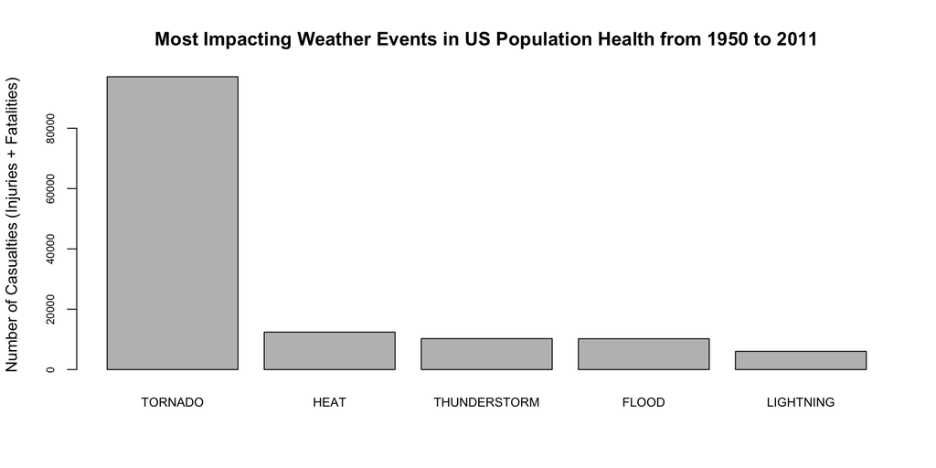

```r
barplot(x[1:5, 2], names.arg=x[1:5, 1], ylab="Number of Casualties (Injuries + Fatalities)", cex.names=0.8, cex.axis=0.7, main="Most Impacting Weather Events in US Population Health from 1950 to 2011")
```

A total of **155673** people were killed or injured due to severe weather events in the United States from January, 1950 to November, 2011.

**Tornados** had the largest impact in US population health, with more than 97 thousands casualties from 1950 to 2011, distantly followed by **heat waves**, **thunderstorms**, **floods** and **lightning**.

### Impact in the Economy

We will aggregate the total estimate value of property and crops damage by the type of severe weather event:

```r
TotalEconomicImpact <- aggregate(EconomicImpact$TOTALDMG, by=list(EconomicImpact$EVTYPE), FUN=sum)
names(TotalEconomicImpact) <- c("EVTYPE", "TOTALDMG")
y<-TotalEconomicImpact[order(TotalEconomicImpact$TOTALDMG, decreasing = TRUE),]
y
```

```
##                    EVTYPE  TOTALDMG
## 24                  FLOOD 1.800e+08
## 42              HURRICANE 9.087e+07
## 56                TORNADO 5.901e+07
## 53       STORM SURGE/TIDE 4.797e+07
## 31                   HAIL 1.902e+07
## 18                DROUGHT 1.502e+07
## 55           THUNDERSTORM 1.225e+07
## 43              ICE STORM 8.991e+06
## 64               WILDFIRE 8.900e+06
## 58         TROPICAL STORM 8.409e+06
## 54       STRONG/HIGH WIND 6.889e+06
## 65   WINTER STORM/WEATHER 6.759e+06
## 34             HEAVY RAIN 4.049e+06
## 26           FROST FREEZE 2.019e+06
```

[output cut: 51 more lines]

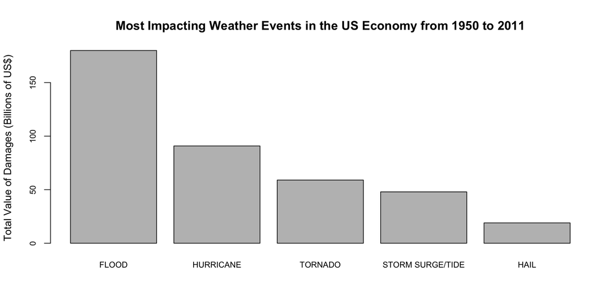

```r
barplot(y[1:5, 2]/1000000, names.arg=y[1:5, 1], ylab="Total Value of Damages (Billions of US$)", cex.names=0.8, cex.axis=0.8, main="Most Impacting Weather Events in the US Economy from 1950 to 2011")
```

A total of **US$476 Billions** were lost due to damages to properties and crops caused by severe weather events in the United States from January, 1950 to November, 2011.

**Floods** had the largest economic impact, with damagens of almost US$ 180 billions from 1950 to 2011, followed by **hurricanes**, **tornados**, **storm surges/tide** and **hail**.